# ANOVA Practice and Examples

2025

## Question 1

You run an experiment with three groups of participants: Control, Treatment A, and Treatment B. Each participant provides one score. You want to test whether there is a difference in means across the groups.

What kind of ANOVA is appropriate, and what are the degrees of freedom for the group effect?

**Click here for the answer**

- **Design:** One-way between-subjects ANOVA
- **Effect of interest:** Group
- **DFn (numerator):** \(3 - 1 = 2\)
- **DFd (denominator):** \(N - 3\)
- **Error term:** Between-subjects residual variance

## Question 2

You run a study where each subject completes a memory task under 4 levels of distraction. You collect one score per condition per subject.

What kind of ANOVA is appropriate, and what are the degrees of freedom for the main effect?

**Click here for the answer**

- **Design:** One-way repeated-measures ANOVA
- **Effect of interest:** Distraction level (within-subjects factor)
- **DFn:** \(4 - 1 = 3\)
- **DFd:** \((4 - 1)(N - 1) = 3(N - 1)\)
- **Error term:** \(A \times \text{Subject}\)
- **Assumption:** Sphericity (test with Mauchly’s test)

## Question 3

You run an experiment with 2 groups (Control vs Training) and 3 testing sessions per subject. Group is a between-subjects factor, Session is a within-subjects factor.

What kind of ANOVA is appropriate, and what are the degrees of freedom for each effect?

**Click here for the answer**

- **Design:** 2 (Group) × 3 (Session) mixed ANOVA
- **Group effect (between):**
  - DFn: \(2 - 1 = 1\)
  - DFd: \(N - 2\)
- **Session effect (within):**
  - DFn: \(3 - 1 = 2\)
  - DFd: \((3 - 1)(N - 2) = 2(N - 2)\)
- **Group × Session interaction:**
  - DFn: \((2 - 1)(3 - 1) = 2\)
  - DFd: same as for Session = \(2(N - 2)\)
- **Error term for within-subjects:** Session × Subject (nested in Group)

## Question 4

You are comparing two groups using a one-way between-subjects ANOVA. Below is a plot of the **population distributions** from which data are assumed to be sampled.

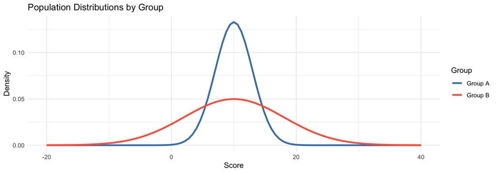

Which ANOVA assumption is violated?

**Click here for the answer**

- The **group means are equal**, so there’s no mean difference.
- But the **variances are unequal**: Group B has a much **wider distribution**.
- This violates the **homogeneity of variance** assumption for between-subjects ANOVA.
- A Levene’s test would likely detect this violation.

## Question 5

A within-subjects factor has 3 levels: A1, A2, A3. Each subject provides one score at each level. The distributions below show the **population-level pairwise differences** between conditions.

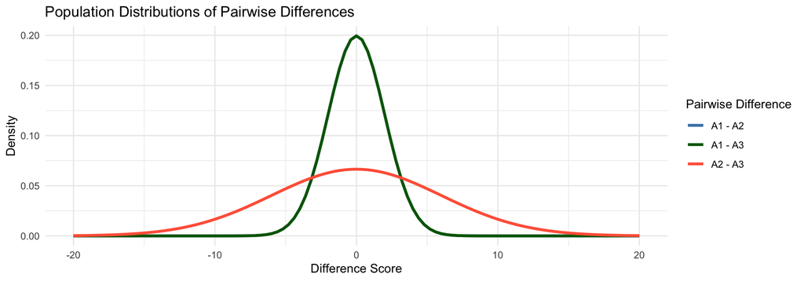

What assumption does this violate?

**Click here for the answer**

- The **sphericity assumption** states that the **variances of all pairwise differences** between levels of a within-subjects factor should be **equal**.
- But here, the variance of the A2 - A3 distribution is clearly **much larger** than the others.
- This is a **violation of sphericity**.
- It would likely be flagged by **Mauchly’s test**, and you’d need a correction like **Greenhouse-Geisser**.

## Question 6

You are running a one-way repeated-measures ANOVA. Each subject provides a score in each of 3 conditions: A1, A2, A3. The plot below shows **sample means with SEM error bars** for each condition.

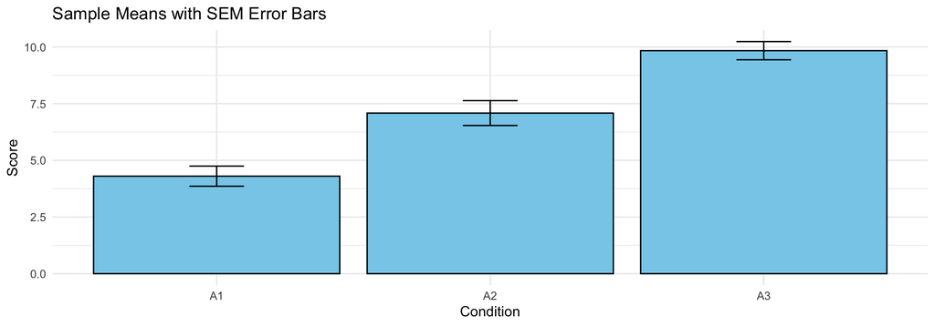

It looks like the spread may differ between conditions. Is any ANOVA assumption violated?

**Click here for the answer**

- No assumption is violated here.
- Although the **bars have different heights**, the **error bars reflect variability around the mean**, not group-level variance differences.
- The **within-subject variance is equal** across conditions (true by design).
- The **sphericity assumption** concerns the **variances of the pairwise differences** between conditions — not the height of the error bars.
- This is a **red herring**: everything is fine for a one-way repeated-measures ANOVA.